# Project3_BlackFriday

Black Friday Sales - Individual Project 3 - DATS 6103

Data Science, Columbian College of Arts & Sciences, George Washington University

Author: Tejaswini Vuppu

- 1.Introduction
  - 1.1. Load the data
  - 1.2. Shape
  - 1.3. Count of NA's
  - 1.4. Drop Product_Category_2 and Product_Category_3
  - 1.5. Name Correction
  - 1.6. Verifying the NA's
  - 1.7. Summary
  - 1.8. Checking Null Values by another method
- 2. EDA
- 3. What are the highest products have been purchased by people on black friday day?
- 4.Which is the highest product category sold on Black Friday?
- 5.On black Friday day, among both genders who pays the most?
- 6.Among both the status single or married who buys the major ?
- 7.Regarding black Friday sales, what age group people are mostly curious ?
- 8.Conclusion
- 9.References

# 1. Introduction

```python
# skipping warnings.
import warnings
warnings.filterwarnings('ignore')
```

# 1.1. Load the data

```python
import pandas as pd
import seaborn as sns # seaborn to visualize plots
import numpy as np
import matplotlib.pyplot as plt

# dataset  website link :- "https://www.kaggle.com/mehdidag/black-friday"

dfRaw = pd.read_csv("BlackFriday.csv",encoding="ISO-8859-1")
```

```python
display(dfRaw.head())
```

|  | User_ID | Product_ID | Gender | Age | Occupation | City_Category | Stay_In_Current_City_Years | Marital_Status | Product_Category_1 | Product_Category_2 | Product_Category_3 | Purchase |
| --- | --- | --- | --- | --- | --- | --- | --- | --- | --- | --- | --- | --- |
| 0 | 1000001 | P00069042 | F | 0-17 | 10 | A | 2 | 0 | 3 | NaN | NaN | 8370 |
| 1 | 1000001 | P00248942 | F | 0-17 | 10 | A | 2 | 0 | 1 | 6.0 | 14.0 | 15200 |
| 2 | 1000001 | P00087842 | F | 0-17 | 10 | A | 2 | 0 | 12 | NaN | NaN | 1422 |
| 3 | 1000001 | P00085442 | F | 0-17 | 10 | A | 2 | 0 | 12 | 14.0 | NaN | 1057 |
| 4 | 1000002 | P00285442 | M | 55+ | 16 | C | 4+ | 0 | 8 | NaN | NaN | 7969 |

# 1.2. Shape

```python
dfRaw.shape
```

```
(537577, 12)
```

# 1.3. Count of NA's

```python
#Checking  for  count of NA's
dfRaw.isna().sum()
```

```
User_ID                            0
Product_ID                         0
Gender                             0
Age                                0
Occupation                         0
City_Category                      0
Stay_In_Current_City_Years         0
Marital_Status                     0
Product_Category_1                 0
Product_Category_2            166986
Product_Category_3            373299
Purchase                           0
dtype: int64
```

By looking at the data Product Category 2& 3 are has more number of NAs lets drop those columns and keep the only column product category1 as category

# 1.4. Drop Product_Category_2 and Product_Category_3

```python
dfRaw = dfRaw.drop(['Product_Category_3',"Product_Category_2"],axis=1)
```

# 1.5. Name Correction

```python
dfRaw.rename(columns={'Product_Category_1':'Product_Category'}, inplace=True)
```

```python
print(dfRaw.shape)
print(dfRaw.columns)
```

```
(537577, 10)
Index(['User_ID', 'Product_ID', 'Gender', 'Age', 'Occupation', 'City_Category',
       'Stay_In_Current_City_Years', 'Marital_Status', 'Product_Category',
       'Purchase'],
      dtype='object')
```

Lets make sure the NA's

# 1.6. Verifying the NA's

```python
dfRaw.isna().sum()
```

```
User_ID                       0
Product_ID                    0
Gender                        0
Age                           0
Occupation                    0
City_Category                 0
Stay_In_Current_City_Years    0
Marital_Status                0
Product_Category              0
Purchase                      0
dtype: int64
```

```python
display(dfRaw.head())
```

|  | User_ID | Product_ID | Gender | Age | Occupation | City_Category | Stay_In_Current_City_Years | Marital_Status | Product_Category | Purchase |
| --- | --- | --- | --- | --- | --- | --- | --- | --- | --- | --- |
| 0 | 1000001 | P00069042 | F | 0-17 | 10 | A | 2 | 0 | 3 | 8370 |
| 1 | 1000001 | P00248942 | F | 0-17 | 10 | A | 2 | 0 | 1 | 15200 |
| 2 | 1000001 | P00087842 | F | 0-17 | 10 | A | 2 | 0 | 12 | 1422 |
| 3 | 1000001 | P00085442 | F | 0-17 | 10 | A | 2 | 0 | 12 | 1057 |
| 4 | 1000002 | P00285442 | M | 55+ | 16 | C | 4+ | 0 | 8 | 7969 |

# 1.7. Summary

```python
#Displays the data frame summary info
dfRaw.info()
```

```
<class 'pandas.core.frame.DataFrame'>
RangeIndex: 537577 entries, 0 to 537576
Data columns (total 10 columns):
User_ID                       537577 non-null int64
Product_ID                    537577 non-null object
Gender                        537577 non-null object
Age                           537577 non-null object
Occupation                    537577 non-null int64
City_Category                 537577 non-null object
Stay_In_Current_City_Years    537577 non-null object
Marital_Status                537577 non-null int64
Product_Category              537577 non-null int64
Purchase                      537577 non-null int64
dtypes: int64(5), object(5)
memory usage: 41.0+ MB
```

# 1.8. Checking Null Values by another method

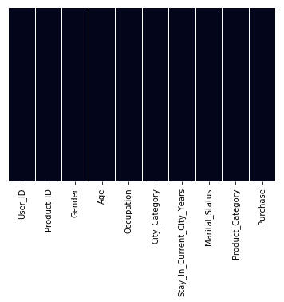

```python
# This is another way to see the nulls on data
sns.heatmap(dfRaw.isnull(), cbar=False,yticklabels=False)
```

## 2. EDA

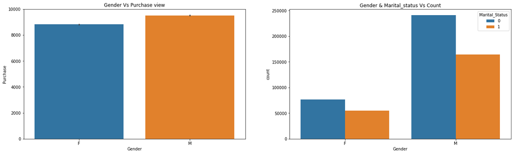

```python
fig,ax = plt.subplots(nrows=1,figsize=(22,6),ncols=2)
sns.barplot(ax=ax[0],estimator=np.mean,x="Gender",data=dfRaw,y="Purchase").set_title('Gender Vs Purchase view')
sns.countplot(data=dfRaw,x="Gender",ax=ax[1],hue="Marital_Status").set_title('Gender & Marital_status Vs Count')
```

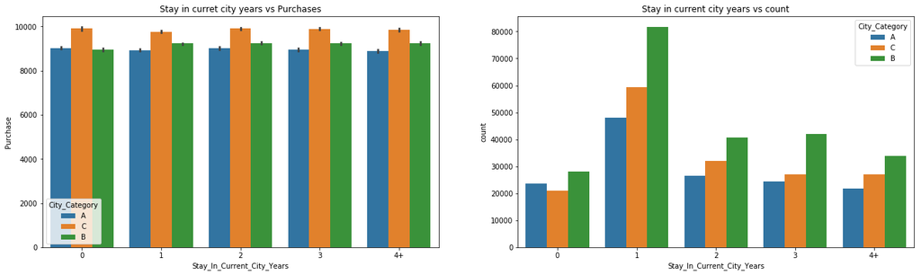

```python
fig,ax = plt.subplots(nrows=1,figsize=(22,6),ncols=2)
sns.barplot(x="Stay_In_Current_City_Years",y="Purchase",hue="City_Category",order=["0","1","2","3","4+"],estimator=np.mean,data=dfRaw,ax=ax[0]).set_title('Stay in curret city years vs Purchases')
sns.countplot(data=dfRaw,x="Stay_In_Current_City_Years",ax=ax[1],hue="City_Category",order=["0","1","2","3","4+"]).set_title('Stay in current city years vs count')
```

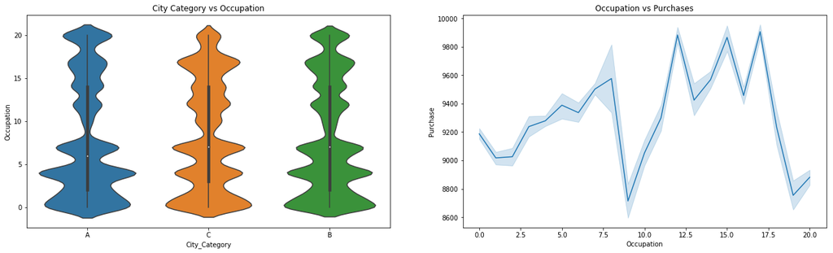

```python
fig,ax = plt.subplots(nrows=1,figsize=(22,6),ncols=2)
sns.violinplot(data=dfRaw,y="Occupation",ax=ax[0],x="City_Category").set_title('City Category vs Occupation')
sns.lineplot(data=dfRaw,y="Purchase",ax=ax[1],x="Occupation").set_title('Occupation vs Purchases')
```

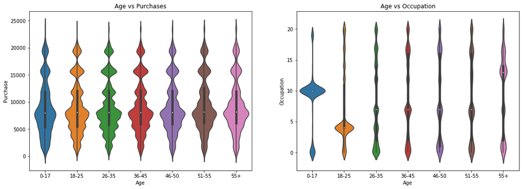

```python
fig,ax = plt.subplots(nrows=1,figsize=(18,6),ncols=2)
sns.violinplot(data=dfRaw,y="Purchase",ax=ax[0],x="Age",order=["0-17","18-25","26-35","36-45","46-50","51-55","55+"]).set_title('Age vs Purchases')
sns.violinplot(data=dfRaw,y="Occupation",ax=ax[1],x="Age",order=["0-17","18-25","26-35","36-45","46-50","51-55","55+"]).set_title('Age vs Occupation')
```

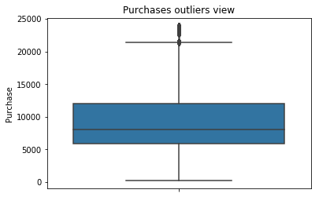

```python
sns.boxplot(data=dfRaw,y="Purchase").set_title('Purchases outliers view')

# The outliers seems to be the one that we deleted for product_category 2 & 3 group purchases
```

## 3. What are the highest products have been purchased by people on black friday day?

```python
#top 10 poducts sold
dfRaw["Product_ID"].value_counts(sort=True)[:15]
```

```
P00110742    1591
P00025442    1586
P00112142    1539
P00057642    1430
P00184942    1424
P00046742    1417
P00059442    1384
P00145042    1384
P00237542    1374
P00010742    1331
P00110842    1260
P00102642    1228
P00242742    1194
P00034742    1188
P00080342    1186
Name: Product_ID, dtype: int64
```

### This data gives an answer, to the above question by taking the count of people that have purchased the products, based on product_id and maximum number bought it.

[figure not shown]

```python
#plotting the top 1- products sold
def simple_bar_plot(data,title = None):

 # A simple bar plot based on pandas plot method Input: data to be plotted and title for the plot
   # Output: the plotled graph

    data.plot("bar",title = title)
    pass
simple_bar_plot(dfRaw["Product_ID"].value_counts(sort=True)[:15], title = "Top 15 products sold")
```

### More than 1100 in quantity are sold by the first 15 products. In the dataset, we don't have the products column explained. We can look at the data and say which products people are fascinated about obtaining.

# 4. Which is the highest product category sold on Black Friday?

[figure not shown]

```python
#plotting the product category
simple_bar_plot(dfRaw["Product_Category_1"].value_counts(sort=True)[:15],
                title = "Top 15 Product Category of people interested")
```

## 5. On black Friday day, among both genders who pays the most?

[figure not shown]

```python
#Check who purchase more
def count_plot(dataframe,column_name,title =None, hue = None):

    #Function to plot seaborn count plot
    #Input: Dataframe name that has to be plotted, column_name that has to be plotted, title for the graph
    #Output: Plot the data as a count plot

    base_color = sns.color_palette()[0]
    sns.countplot(data = dataframe,x = column_name,hue=hue)
    plt.title(title)
    pass
count_plot(dfRaw,"Gender","Male or Female who pays most?","Gender")
```

## 6. Among both the status single or married who buys the major ?

[figure not shown]

```python
#Let see
count_plot(dfRaw,"Marital_Status","Marital Status of Buyers",)
```

### When we look at the graph, there is plotting with value 0 & 1, which doesn't give much information about it. Now, let's again plot it with a proper legend.

[figure not shown]

```python
#Let us create class handler to get the legend displayed in the plot
from matplotlib.legend_handler import HandlerBase
from matplotlib.text import Text
class TextHandler(HandlerBase):

    def create_artists(self, legend, tup ,xdescent, ydescent,width, height, fontsize,trans):

        #Function to display legend for a plot
        #Input: legend, tuple string, placement of x and y descent, width and hight, font for the legend
        #Output: retuns the text for legend
        #self, legend, tup ,xdescent, ydescent,width, height, fontsize,trans
        tx = Text(width/2.,height/2,tup[0], fontsize=fontsize,
                  ha="center", va="center", color=tup[1], fontweight="bold")
        return [tx]





ax=sns.countplot(dfRaw.Marital_Status)
#creating the mapping text for the values
handltext = ["0", "1"]
labels = ["Individual", "Married"]
#get the X axis tick labels
t = ax.get_xticklabels()
#map the x values as key and values
labeldic = dict(zip(handltext, labels))
labels = [labeldic[h.get_text()]  for h in t]
handles = [(h.get_text(),c.get_fc()) for h,c in zip(t,ax.patches)]
ax.legend(handles, labels, handler_map={tuple : TextHandler()})
plt.title("Marital Status of the Buyers")
plt.show()
```

[figure not shown]

```python
sns.heatmap(dfRaw.corr(),fmt = '.2f', center = 0,annot = True,cmap = 'vlag_r')
```

## 7. Regarding black Friday sales, what age group people are mostly curious ?

```python
#we need to look the value counts of the age column
dfRaw.Age.value_counts()
```

[output not shown]

[figure not shown]

```python
#sns.countplot(df['Age'])
count_plot(dfRaw,"Age","Age Group of Buyers")
#dfRaw,"Age","Age Group of Buyers"
```

### Among all age group people, most of them are from 26-35. We can also find within age groups, which gender was the more by adding 'hue' parameter to the syntax. When we look at it the majority is spent by males when compared with females.

[figure not shown]

```python
count_plot(dfRaw,"Age","Age Group vs Marital Status", "Gender")
```

### Let's see the Age group vs Marital status of the person based on Gender. We need to group the persons buying in the age group and check the gender whether they are male or female. We are also eager to know the marital status of them.

### We have found a feature where we will connect the Gender & Marital Status. Then we will relate that with Age group.

```python
dfRaw['combined_G_M'] = dfRaw.apply(lambda x:'%s_%s' % (x['Gender'],x['Marital_Status']),axis=1)
print(dfRaw['combined_G_M'].unique())
```

[output not shown]

[figure not shown]

```python
count_plot(dfRaw,"Age","Age vs Gender vs Marital Status", "combined_G_M")
#dfRaw,"Age","Age vs Gender vs Marital Status", "combined_G_M"
```

# 8. Conclusion

### According to barplot above, there are no bars in the range 0-17 for married (M_1) and Female (F_1) which gives us some information. When we see age groups from 46 and above, Females are doing less when compared with males. On the contrast, when we look at the married men investing more money on Black Friday sales associated with married women. We all knew that women do shopping a lot but their spouses i.e., husband sponsor money for them. So the data reflects as it is men's expense. If we know some more information like categorical data about products purchased by men, we might have gone some more detailed into it. Finally, I conclude saying that, we don't know until unless there is a category that belongs to feminine products/clothes in this dataset.We cannot effort much time examining this topic.

# 9.References

- https://www.kaggle.com/
- https://pandas.pydata.org/
- http://www.numpy.org/
- https://matplotlib.org/